# Lab 1 - Insertion Sort

Author: Kevin Paganini  
Date: 3/7/2023  
Description: In this lab I write implementations of Insertion sort as well as Selection sort. Once that has been completed I tested the algorithms for correctness on a couple axams and ran benchmark tests with different list sizes. Finally, I did some analysis and visualizations of the runtimes for each algorithm and compared the two as well.

```python
import pandas as pd
import matplotlib.pyplot as plt
import numpy as np
import random
import timeit
from time import perf_counter


# makes plots nice
def make_pretty(ax, title='', x_label='', y_label='', img=False):
    ax.set_title(title, fontsize=20)
    ax.set_xlabel(x_label, fontsize=16)
    ax.set_ylabel(y_label, fontsize=16)
    ax.legend(loc='best', fontsize=16)
    if img:
        ax.axis('off')
    return ax
```

### Implementation of Selection and Insertion Sort

```python
def insertion_sort(lst):
    for j in range(1, len(lst)):
        check = lst[j]

        i = j - 1
        while i >= 0 and lst[i] > check:
            lst[i + 1] = lst[i]
            i -= 1
        lst[i + 1] = check

    return lst




def selection_sort(lst):
    for j in range(len(lst) - 1):
        smallest = j

        for i in range(j + 1, len(lst)):
            if lst[i] < lst[smallest]:
                smallest = i

        temp = lst[j]
        lst[j] = lst[smallest]
        lst[smallest] = temp


    return lst
```

### Insertion Sort Tests

```python
print(insertion_sort([3, 9, 2, 5, 1]))
print(insertion_sort([1, 2, 3, 4, 5]))
print(insertion_sort([5, 4, 3, 2, 1]))
print(insertion_sort([4, 9, 1, 5, 2, 0, -4, 90, 12, 43, -100, 54, 1, 9, 19]))
```

```
[1, 2, 3, 5, 9]
[1, 2, 3, 4, 5]
[1, 2, 3, 4, 5]
[-100, -4, 0, 1, 1, 2, 4, 5, 9, 9, 12, 19, 43, 54, 90]
```

### Selection Sort Tests

```python
print(selection_sort([3, 9, 2, 5, 1]))
print(selection_sort([1, 2, 3, 4, 5]))
print(selection_sort([5, 4, 3, 2, 1]))
print(selection_sort([4, 9, 1, 5, 2, 0, -4, 90, 12, 43, -100, 54, 1, 9, 19]))
```

```
[1, 2, 3, 5, 9]
[1, 2, 3, 4, 5]
[1, 2, 3, 4, 5]
[-100, -4, 0, 1, 1, 2, 4, 5, 9, 9, 12, 19, 43, 54, 90]
```

### Benchmarking function

```python
def benchmark_time(algo, lst):
    start = perf_counter()
    x = algo(lst)
    end = perf_counter()
    return end - start
```

## Making test cases

### Random order selection sort

```python
# random list 100
ret = []
for i in range(5):
    y = benchmark_time(selection_sort, [random.randint(0, 1000) for _ in range(100)])
    ret.append(y)
print(f'Mean time for random list with 100 elements: {np.mean(ret)}')

# random list 1000
ret = []
for i in range(5):
    y = benchmark_time(selection_sort, [random.randint(0, 1000) for _ in range(1000)])
    ret.append(y)
print(f'Mean time for random list with 1000 elements: {np.mean(ret)}')

# random list 10000
ret = []
for i in range(5):
    y = benchmark_time(selection_sort, [random.randint(0, 1000) for _ in range(10000)])
    ret.append(y)
print(f'Mean time for random list with 10000 elements: {np.mean(ret)}')

# random list 50000
ret = []
for i in range(5):
    print(f'iteration: {i}')
    y = benchmark_time(selection_sort, [random.randint(0, 1000) for _ in range(50000)])
    ret.append(y)
print(f'Mean time for random list with 50000 elements: {np.mean(ret)}')

# random list 100000
ret = []
for i in range(5):
    print(f'iteration: {i}')
    y = benchmark_time(selection_sort, [random.randint(0, 1000) for _ in range(100000)])
    ret.append(y)
print(f'Mean time for random list with 100000 elements: {np.mean(ret)}')
```

[output not shown]

### Random Order tests - insertion sort

```python
# random list 100
ret = []
for i in range(5):
    y = benchmark_time(insertion_sort, [random.randint(0, 1000) for _ in range(100)])
    ret.append(y)
print(f'Mean time for random list with 100 elements: {np.mean(ret)}')

# random list 1000
ret = []
for i in range(5):
    y = benchmark_time(insertion_sort, [random.randint(0, 1000) for _ in range(1000)])
    ret.append(y)
print(f'Mean time for random list with 1000 elements: {np.mean(ret)}')

# random list 10000
ret = []
for i in range(5):
    y = benchmark_time(insertion_sort, [random.randint(0, 1000) for _ in range(10000)])
    ret.append(y)
print(f'Mean time for random list with 10000 elements: {np.mean(ret)}')

# random list 50000
ret = []
for i in range(5):
    print(f'iteration: {i}')
    y = benchmark_time(insertion_sort, [random.randint(0, 1000) for _ in range(50000)])
    ret.append(y)
print(f'Mean time for random list with 50000 elements: {np.mean(ret)}')

# random list 100000
ret = []
for i in range(5):
    print(f'iteration: {i}')
    y = benchmark_time(insertion_sort, [random.randint(0, 1000) for _ in range(100000)])
    ret.append(y)
print(f'Mean time for random list with 100000 elements: {np.mean(ret)}')
```

```
Mean time for random list with 100 elements: 0.0002574800048023462
Mean time for random list with 1000 elements: 0.02130955999600701
Mean time for random list with 10000 elements: 2.0544201800075825
iteration: 0
iteration: 1
iteration: 2
iteration: 3
iteration: 4
Mean time for random list with 50000 elements: 51.380413240002234
iteration: 0
iteration: 1
iteration: 2
iteration: 3
iteration: 4
Mean time for random list with 100000 elements: 214.88900324000278
```

### Sorted tests - selection sort

```python
# random list 100
ret = []
for i in range(5):
    y = benchmark_time(selection_sort, [x for x in range(100)])
    ret.append(y)
print(f'Mean time for sorted list with 100 elements: {np.mean(ret)}')

# random list 1000
ret = []
for i in range(5):
    y = benchmark_time(selection_sort, [x for x in range(1000)])
    ret.append(y)
print(f'Mean time for sorted list with 1000 elements: {np.mean(ret)}')

# random list 10000
ret = []
for i in range(5):
    y = benchmark_time(selection_sort, [x for x in range(10000)])
    ret.append(y)
print(f'Mean time for sorted list with 10000 elements: {np.mean(ret)}')

# random list 50000
ret = []
for i in range(5):
    print(f'iteration: {i}')
    y = benchmark_time(selection_sort, [x for x in range(50000)])
    ret.append(y)
print(f'Mean time for sorted list with 500000 elements: {np.mean(ret)}')

# random list 100000
ret = []
for i in range(5):
    print(f'iteration: {i}')
    y = benchmark_time(selection_sort, [x for x in range(100000)])
    ret.append(y)
print(f'Mean time for sorted list with 100000 elements: {np.mean(ret)}')
```

```
Mean time for sorted list with 100 elements: 0.0004420599958393723
Mean time for sorted list with 1000 elements: 0.019136239995714278
Mean time for sorted list with 10000 elements: 1.9170182600035333
iteration: 0
iteration: 1
iteration: 2
iteration: 3
iteration: 4
Mean time for sorted list with 500000 elements: 46.954555200005416
iteration: 0
iteration: 1
iteration: 2
iteration: 3
iteration: 4
Mean time for sorted list with 100000 elements: 187.40194183999557
```

### Sorted tests - insertion sort

```python
# random list 100
ret = []
for i in range(5):
    y = benchmark_time(insertion_sort, [x for x in range(100)])
    ret.append(y)
print(f'Mean time for sorted list with 100 elements: {np.mean(ret)}')

# random list 1000
ret = []
for i in range(5):
    y = benchmark_time(insertion_sort, [x for x in range(1000)])
    ret.append(y)
print(f'Mean time for sorted list with 1000 elements: {np.mean(ret)}')

# random list 10000
ret = []
for i in range(5):
    y = benchmark_time(insertion_sort, [x for x in range(10000)])
    ret.append(y)
print(f'Mean time for sorted list with 10000 elements: {np.mean(ret)}')

# random list 50000
ret = []
for i in range(5):
    print(f'iteration: {i}')
    y = benchmark_time(insertion_sort, [x for x in range(50000)])
    ret.append(y)
print(f'Mean time for sorted list with 500000 elements: {np.mean(ret)}')

# random list 100000
ret = []
for i in range(5):
    print(f'iteration: {i}')
    y = benchmark_time(insertion_sort, [x for x in range(100000)])
    ret.append(y)
print(f'Mean time for sorted list with 100000 elements: {np.mean(ret)}')
```

```
Mean time for sorted list with 100 elements: 0.00011209999793209136
Mean time for sorted list with 1000 elements: 0.00012015999527648091
Mean time for sorted list with 10000 elements: 0.0011457599990535527
iteration: 0
iteration: 1
iteration: 2
iteration: 3
iteration: 4
Mean time for sorted list with 500000 elements: 0.005059479997726157
iteration: 0
iteration: 1
iteration: 2
iteration: 3
iteration: 4
Mean time for sorted list with 100000 elements: 0.00965628000558354
```

### Reverse Sorted - selection sort

```python
# random list 100
ret = []
for i in range(5):
    y = benchmark_time(selection_sort, [x for x in range(100, 0, -1)])
    ret.append(y)
print(f'Mean time for sorted list with 100 elements: {np.mean(ret)}')

# random list 1000
ret = []
for i in range(5):
    y = benchmark_time(selection_sort, [x for x in range(1000, 0, -1)])
    ret.append(y)
print(f'Mean time for sorted list with 1000 elements: {np.mean(ret)}')

# random list 10000
ret = []
for i in range(5):
    y = benchmark_time(selection_sort, [x for x in range(10000, 0, -1)])
    ret.append(y)
print(f'Mean time for sorted list with 10000 elements: {np.mean(ret)}')

# random list 50000
ret = []
for i in range(5):
    print(f'iteration: {i}')
    y = benchmark_time(selection_sort, [x for x in range(50000, 0, -1)])
    ret.append(y)
print(f'Mean time for sorted list with 500000 elements: {np.mean(ret)}')

# random list 100000
ret = []
for i in range(5):
    print(f'iteration: {i}')
    y = benchmark_time(selection_sort, [x for x in range(100000, 0, -1)])
    ret.append(y)
print(f'Mean time for sorted list with 100000 elements: {np.mean(ret)}')
```

```
Mean time for sorted list with 100 elements: 0.00034179999493062497
Mean time for sorted list with 1000 elements: 0.02080720000085421
Mean time for sorted list with 10000 elements: 1.945117100002244
iteration: 0
iteration: 1
iteration: 2
iteration: 3
iteration: 4
Mean time for sorted list with 500000 elements: 50.09105787999579
iteration: 0
iteration: 1
iteration: 2
iteration: 3
iteration: 4
Mean time for sorted list with 100000 elements: 199.31769160000258
```

### Reverse Sorted - insertion sort

```python
# random list 100
ret = []
for i in range(5):
    y = benchmark_time(insertion_sort, [x for x in range(100, 0, -1)])
    ret.append(y)
print(f'Mean time for sorted list with 100 elements: {np.mean(ret)}')

# random list 1000
ret = []
for i in range(5):
    y = benchmark_time(insertion_sort, [x for x in range(1000, 0, -1)])
    ret.append(y)
print(f'Mean time for sorted list with 1000 elements: {np.mean(ret)}')

# random list 10000
ret = []
for i in range(5):
    y = benchmark_time(insertion_sort, [x for x in range(10000, 0, -1)])
    ret.append(y)
print(f'Mean time for sorted list with 10000 elements: {np.mean(ret)}')

# random list 50000
ret = []
for i in range(5):
    print(f'iteration: {i}')
    y = benchmark_time(insertion_sort, [x for x in range(50000, 0, -1)])
    ret.append(y)
print(f'Mean time for sorted list with 500000 elements: {np.mean(ret)}')

# random list 100000
ret = []
for i in range(5):
    print(f'iteration: {i}')
    y = benchmark_time(insertion_sort, [x for x in range(100000, 0, -1)])
    ret.append(y)
print(f'Mean time for sorted list with 100000 elements: {np.mean(ret)}')
```

```
Mean time for sorted list with 100 elements: 0.00048248000093735753
Mean time for sorted list with 1000 elements: 0.03732382000307553
Mean time for sorted list with 10000 elements: 3.954757479997352
iteration: 0
iteration: 1
iteration: 2
iteration: 3
iteration: 4
Mean time for sorted list with 500000 elements: 100.3001846399915
iteration: 0
iteration: 1
iteration: 2
iteration: 3
iteration: 4
Mean time for sorted list with 100000 elements: 406.00463165999975
```

|  | Insertion sort (reverse sorted) | Insertion sort (sorted) | Insertion sort (random) |
| --- | --- | --- | --- |
| 100 | 0.0005 | 0.00011 | 0.00025 |
| 1000 | 0.037 | 0.00012 | 0.021 |
| 10000 | 3.95 | 0.0012 | 2.05 |
| 50000 | 100.3 | 0.005 | 51.4 |
| 100000 | 406 | 0.0096 | 214.9 |

|  | Selection sort (reverse sorted) | Selection sort (sorted) | Selection sort (random) |
| --- | --- | --- | --- |
| 100 | 0.0003 | 0.00044 | 0.0003 |
| 1000 | 0.02 | 0.02 | 0.02 |
| 10000 | 1.95 | 1.9 | 2.005 |
| 50000 | 50.1 | 46.9 | 50.12 |
| 100000 | 199.3 | 187.4 | 207 |

## Validating formal run times

Insertion Sort

```python
from scipy.stats import linregress

# reverse case
run_times = [0.0005, 0.037, 3.95, 100.3, 406]
x = linregress(np.log([100, 1000, 10000, 50000, 100000]), np.log(run_times))

print(f'The slope of the reverse case is: {x.slope}')

# sorted case
run_times = [0.00011, 0.00012, 0.0012, 0.005, 0.0096]
x = linregress(np.log([100, 1000, 10000, 50000, 100000]), np.log(run_times))

print(f'The slope of the sorted case is: {x.slope}')

# average
run_times = [0.00025, 0.021, 2.05, 51.4, 214.9]
x = linregress(np.log([100, 1000, 10000, 50000, 100000]), np.log(run_times))

print(f'The slope of the average case is: {x.slope}')
```

```
The slope of the reverse case is: 1.9779544857222227
The slope of the sorted case is: 0.6955905787688826
The slope of the average case is: 1.9787547573798996
```

Selection Sort

```python
# reverse case
run_times = [0.0003, 0.02, 1.95, 50.1, 199.3]
x = linregress(np.log([100, 1000, 10000, 50000, 100000]), np.log(run_times))

print(f'The slope of the reverse case is: {x.slope}')

# sorted case
run_times = [0.00044, 0.02, 1.9, 46.9, 187.4]
x = linregress(np.log([100, 1000, 10000, 50000, 100000]), np.log(run_times))

print(f'The slope of the sorted case is: {x.slope}')

# average
run_times = [0.0003, 0.02, 2.005, 50.12, 207]
x = linregress(np.log([100, 1000, 10000, 50000, 100000]), np.log(run_times))

print(f'The slope of the average case is: {x.slope}')
```

```
The slope of the reverse case is: 1.9495432484924453
The slope of the sorted case is: 1.8920625732380634
The slope of the average case is: 1.9534548301116788
```

Selection sort has a consistent run time throughout of almost $n^2$. Insertion sort may be good to use when it is presorted slightly.

[figure not shown]

```python
fig, ax = plt.subplots(figsize=(15, 10))

ax.plot([100, 1000, 10000, 50000, 100000], [0.0003, 0.02, 2.005, 50.12, 207], label='avg')
ax.plot([100, 1000, 10000, 50000, 100000], [0.00044, 0.02, 1.9, 46.9, 187.4], label='sorted')
ax.plot([100, 1000, 10000, 50000, 100000], [0.0003, 0.02, 1.95, 50.1, 199.3], label='reverse sorted')
make_pretty(ax, 'Selection sort runtimes', 'list sizes', 'runtime in seconds')
```

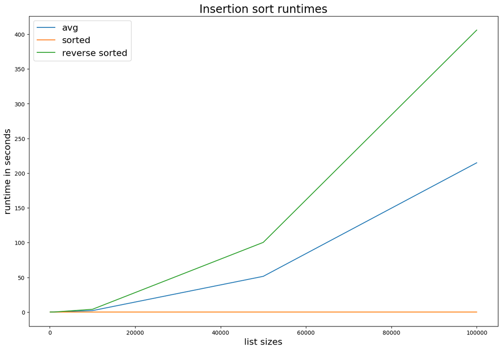

```python
fig, ax = plt.subplots(figsize=(15, 10))

ax.plot([100, 1000, 10000, 50000, 100000], [0.00025, 0.021, 2.05, 51.4, 214.9], label='avg')
ax.plot([100, 1000, 10000, 50000, 100000], [0.00011, 0.00012, 0.0012, 0.005, 0.0096], label='sorted')
ax.plot([100, 1000, 10000, 50000, 100000], [0.0005, 0.037, 3.95, 100.3, 406], label='reverse sorted')
make_pretty(ax, 'Insertion sort runtimes', 'list sizes', 'runtime in seconds')
```

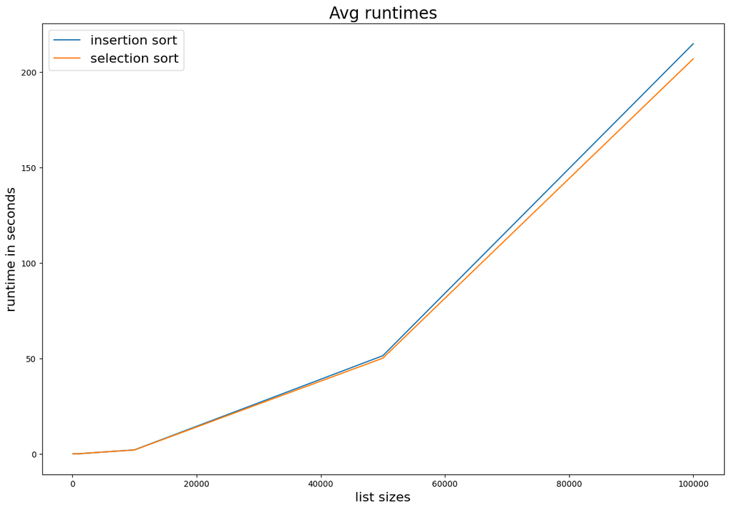

```python
fig, ax = plt.subplots(figsize=(15, 10))

ax.plot([100, 1000, 10000, 50000, 100000], [0.00025, 0.021, 2.05, 51.4, 214.9], label='insertion sort')
ax.plot([100, 1000, 10000, 50000, 100000], [0.0003, 0.02, 2.005, 50.12, 207], label='selection sort')
make_pretty(ax, 'Avg runtimes', 'list sizes', 'runtime in seconds')
```

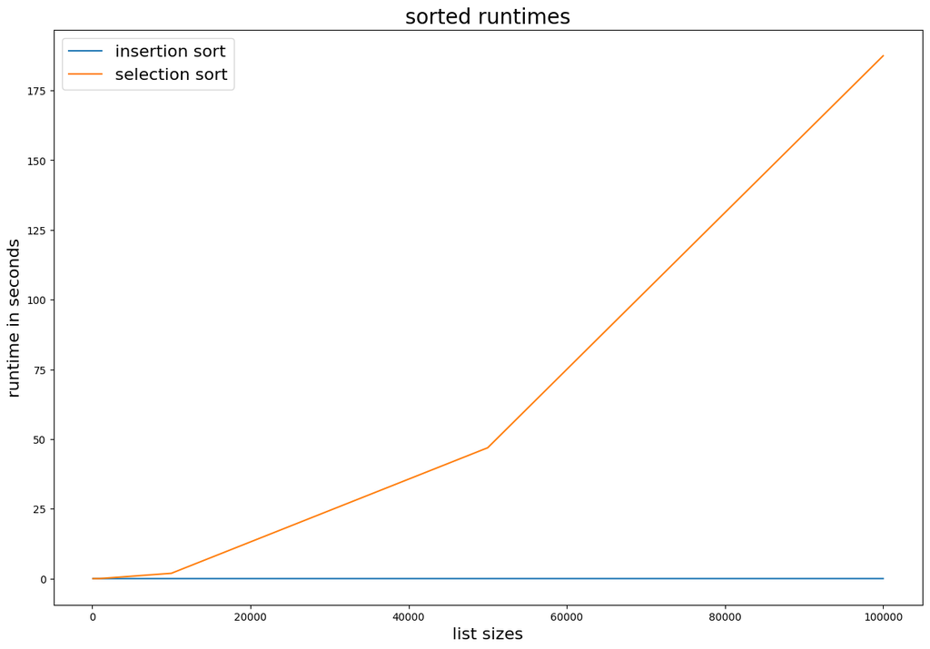

```python
fig, ax = plt.subplots(figsize=(15, 10))

ax.plot([100, 1000, 10000, 50000, 100000], [0.00011, 0.00012, 0.0012, 0.005, 0.0096], label='insertion sort')
ax.plot([100, 1000, 10000, 50000, 100000], [0.00044, 0.02, 1.9, 46.9, 187.4], label='selection sort')
make_pretty(ax, 'sorted runtimes', 'list sizes', 'runtime in seconds')
```

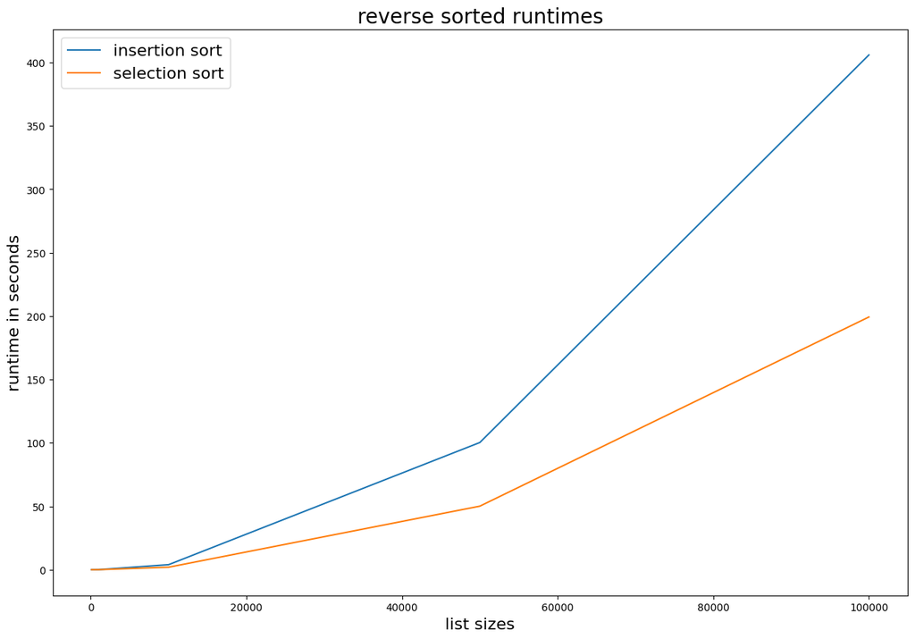

```python
fig, ax = plt.subplots(figsize=(15, 10))

ax.plot([100, 1000, 10000, 50000, 100000], [0.0005, 0.037, 3.95, 100.3, 406], label='insertion sort')
ax.plot([100, 1000, 10000, 50000, 100000], [0.0003, 0.02, 1.95, 50.1, 199.3], label='selection sort')
make_pretty(ax, 'reverse sorted runtimes', 'list sizes', 'runtime in seconds')
```

### 6. Reflection Questions

1. Create a table of the theoretical and estimated run time functions for the 6 combos. Do your estimates match the theory?

|  | Selection sort (reverse sorted) | Selection sort (sorted) | Selection sort (random) |
| --- | --- | --- | --- |
| theor | $n^2$ | $n^2$ | $n^2$ |
| exper | $n^2$ | $n^2$ | $n^2$ |

|  | Insertion sort (reverse sorted) | Insertion sort (sorted) | Insertion sort (random) |
| --- | --- | --- | --- |
| theor | $n^2$ | $n$ | $n^2$ |
| exper | $n^2$ | $n$ | $n^2$ |

Theoretically in insertion sort if the list is sorted in ascending order, it will never go into the inner while loop and it will simply be $O(n)$. In the worst case scenario, the list is reverse sorted and will then be $O(n^2)$. In a random ordered list, it will have to go into the inner loop not every time and will also be $O(n^2)$.

In selection sort, no matter what, it will have two complete to for loops, however as the algorithm continues the number of iterations the inner loop has to do decreases. Since there are no real optimizations for different cases, the runtimes are equivalent for all cases. Hence the runtime is $O(n^2)$ for all.

All this to say that yes the estimates match the theory.

2. Which algorithm had a better run time than the other and for which case? Why do you think that one case was substantially faster for that algorithm? (Hint: focus on the inner loops.)
- The insertion sort algorithm has a better runtime for the sorted case, because of the short circuiting nature of the inner while loop. The while loop has conditions on it that will stop it from looping all the way once it has found the spot to insert the element.
- In the case where the list was initialized in random order, both algorithms performed very similaryl in runtime and there was no clear winner.
- In the reverse sorted case the selection sort algorithm had a better runtime. Both algorithms have similar looping structures in the inner loop in that it does not always go to n. In insertion sort the first time through it only has to loop through once. In selection sort in the last time through the algorithm has to only loop through once as well. Insertion sorts inner loop goes from 1 (the first loop) to n (the last loop), while selection sort goes from n (the first loop) to 1 (the last loop). The reason why selection sort is doubly as fast as insertion sort is due to the fact that it does not switch elements from within the inner loop. Insertion sort must switch elements in the list every time it runs the while loop, while selection sort only has to switch once at the end of the outer for loop.
3. Based on your results, which of the two sorting algorithms would you use in practice?
- Which sorting algorithm I would use depends on the use case of the algorithm and what state the list is in when given to the sorting algorithm. If the list were already sorted for the most part and just some outliers need to be mvoed around, I would use insertion sort as this has a better runtime when using sorted lists. If the list were in reverse sorted order, I would use selection sort as this runs doubly as fast as the counterpart.